# 05. Summarize Data

DSST289: Introduction to Data Science

Author

Erik Fredner

Published

September 8, 2024

## The `summarize` verb

In the previous notebook we introduced the concept of data *verbs*. Four useful examples were shown: `slice` and `filter` for taking a subset of rows, `select` for taking a subset of columns, and `arrange` for reordering a data set’s rows. In this notebook we discuss another important verb, `summarize` that collapses a data frame by using summary functions. Using this verb is slightly more involved because we have to explain exactly how the data should be summarized. We will introduce several helper functions to make this process slightly easier.

Before describing the syntax for the summarize function, let’s start with an example. `summarize` works with summary functions, such as `sum` or `mean`:

```r
data <- c(1, 2, 3, 4, 5)
sum(data)
```

```
[1] 15
```

```r
mean(data)
```

```
[1] 3
```

Here, we summarize our food data set by indicating the mean (average) value of the sugar variable across the entire data set:

```r
food |>
  summarize(sugar_mean = mean(sugar)) |>
  # `print` makes it clearer what is happening:
  print()
```

```
# A tibble: 1 × 1
  sugar_mean
       <dbl>
1       3.42
```

Here we used the function `mean` inside of the function `summarize` to produce the output. We specified which variable to compute the mean of by giving its name inside of the `mean` function. Note that we need to define what the name of the new variable is.

You’ll also notice that this produces a 1x1 table, where the row contains the mean value of the sugar variable. It may seem odd that this result is a table but we will see that this is a useful feature when we start to group data.

### What about a single `mean` without a table?

If you want to compute a single summary statistic without creating a new table, you can use the `pull` function to extract a single column from a data set. See [the documentation on `pull()`](https://dplyr.tidyverse.org/reference/pull.html).

```r
food |>
  # pull the column named sugar
  pull(sugar) |>
  mean()
```

```
[1] 3.418852
```

The results shows us that the average amount of sugar in a 100g portion of all of the foods is 3.419g.

In order to compute multiple summaries at once, we can pass multiple functions together are once. For example, here we compute the mean value of three nutritional measurements:

```r
food |>
  summarize(
    sugar_mean = mean(sugar),
    calories_mean = mean(calories),
    vitamin_a_mean = mean(vitamin_a)
  )
```

| sugar_mean | calories_mean | vitamin_a_mean |
| --- | --- | --- |
| 3.418852 | 113.5082 | 16.06557 |

Notice that R creates a new data set with the variable names we supplied above. There are a number of other useful summary functions that work similarly, such as `min`, `max`, `sum`, and `sd` (standard deviation). We will see examples of these later.

## Grouped summaries

Summarizing the data set to a single row can be useful for understanding the general trends in a data set or highlighting outliers. However, the real power of the summary function comes when we pair it with grouped manipulations. This will allow us to produce summaries *within* one or more grouping variables in our data set.

When we use the `group_by` function, subsequent uses of the `summarize` function will produce a summary that describes the properties of variables within the variable used for grouping. The variable name(s) placed inside of the `group_by` function indicate which variable(s) should be used for the groups. For example, here we compute the mean number of calories of each food group:

```r
food |>
  group_by(food_group) |>
  summarize(calories_mean = mean(calories))
```

| food_group | calories_mean |
| --- | --- |
| dairy | 180.7500 |
| fish | 166.9286 |
| fruit | 54.9375 |
| grains | 195.8000 |
| meat | 234.5000 |
| vegetable | 37.4375 |

Notice that the output data set contains a column for the grouping variable (`food_group`) and the summarized variable (`calories_mean`). The summarized variable name is exactly the same as the non-grouped version and the final line of code looks exactly the same as before. However, the output data set now contains six rows, one for each food group.

Any summarization function that can be used for an ungrouped data set can also be used for a grouped data set. Also, as before, we can put multiple summary functions together to obtain different measurements of each group.

```r
food |>
  group_by(food_group) |>
  summarize(
    sugar_mean = mean(sugar),
    calories_mean = mean(calories),
    total_fat_mean = mean(total_fat)
  )
```

| food_group | sugar_mean | calories_mean | total_fat_mean |
| --- | --- | --- | --- |
| dairy | 6.9000000 | 180.7500 | 13.025000 |
| fish | 0.3257143 | 166.9286 | 7.221429 |
| fruit | 8.0462500 | 54.9375 | 1.043750 |
| grains | 1.2400000 | 195.8000 | 2.560000 |
| meat | 0.0000000 | 234.5000 | 13.916667 |
| vegetable | 2.5906250 | 37.4375 | 0.281250 |

Notice that the variable names (e.g., `sugar_mean`) should make it clear which column corresponds to each summary function.

## More summary functions

### `n()`

There are several additional summary functions that will be useful for analyzing data. The function `n()` takes no arguments and returns a value that **counts the total number of rows in the data set**.

This isn’t useful for data frames by themselves. You can see the number of rows in a regular `tibble` by using the `count` function from the `dplyr` package:

```r
food |>
  count() |>
  # easier to interpret with `print`:
  print()
```

```
# A tibble: 1 × 1
      n
  <int>
1    61
```

However, when we group data, the `n()` function becomes more useful:

```r
food |>
  group_by(food_group) |>
  summarize(n = n())
```

| food_group | n |
| --- | --- |
| dairy | 4 |
| fish | 14 |
| fruit | 16 |
| grains | 5 |
| meat | 6 |
| vegetable | 16 |

This tells us how many rows are in each group. This can be useful to figure out how many items are in each group, or to see if there are any groups that are missing data.

### `n_distinct()`

The `n_distinct` function counts the number of unique (distinct) values in a column. This is more useful for data sets that contain repeated observations.

For example, let’s look at a sample of food pricing data over time:

| year | food | price |
| --- | --- | --- |
| 1872 | pork | 58.64472 |
| 1891 | barley | 118.36735 |
| 1898 | cocoa | 96.85520 |
| 1900 | cocoa | 100.00000 |
| 1901 | pork | 115.34598 |
| 1916 | cocoa | 64.66065 |
| 1941 | peanuts | 83.78337 |
| 1994 | rye | 29.60072 |
| 2001 | beef | 130.92912 |
| 2012 | cocoa | 24.33900 |

This is a big table, and it’s not obvious how many unique types of food are included in `food`. We can use `n_distinct` to find out:

```r
food_prices_longer |>
  summarize(distinct_foods = n_distinct(food))
```

| distinct_foods |
| --- |
| 13 |

And we can see what those are with `pull` and `unique`:

```r
food_prices_longer |>
  pull(food) |>
  unique()
```

```
 [1] "tea"     "sugar"   "peanuts" "coffee"  "cocoa"   "wheat"   "rye"
 [8] "rice"    "corn"    "barley"  "pork"    "beef"    "lamb"
```

`n_distinct()` is different from `n()`, which counts the number of observations of each value:

```r
food_prices_longer |>
  group_by(food) |>
  summarize(n = n())
```

| food | n |
| --- | --- |
| barley | 146 |
| beef | 146 |
| cocoa | 146 |
| coffee | 146 |
| corn | 146 |
| lamb | 146 |
| peanuts | 146 |
| pork | 146 |
| rice | 146 |
| rye | 146 |

[output cut: 3 more lines]

### `paste()`

The summary function `paste` collapses all of the values in a character variable. For example, applying this summary it to the `item` category after grouping by color, we can see all of the foods in the data set associated with a specific color:

```r
food |>
  group_by(color) |>
  summarize(items = paste(item, collapse = "|")) |>
  # `print`ing the result to make it clear what's happening:
  print()
```

```
# A tibble: 8 × 2
  color  items
  <chr>  <chr>
1 brown  Chickpea|Mushroom|Oat|Quinoa|Brown Rice
2 green  Asparagus|Avocado|String Bean|Bell Pepper|Broccoli|Cabbage|Celery|…
3 orange Cantaloupe|Carrot|Orange|Sweet Potato|Tangerine
4 pink   Grapefruit|Peach|Salmon|Shrimp
5 purple Grape|Plum
6 red    Apple|Beef|Crab|Duck|Lamb|Lobster|Strawberry|Tomato|Tuna
7 white  Catfish|Cauliflower|Chicken|Clam|Cod|Flounder|Halibut|Haddock|Milk…
8 yellow Banana|Cheese|Corn|Lemon|Pineapple
```

## Geometries for summaries

We can use summarized data sets to produce new data visualizations. For example, consider summarizing the average number of calories, average total fat, and number of items in each food groups. We can take this data and construct a scatter plot that shows the average fat and calories of each food group, along with informative labels. Here’s the code to make this visualization:

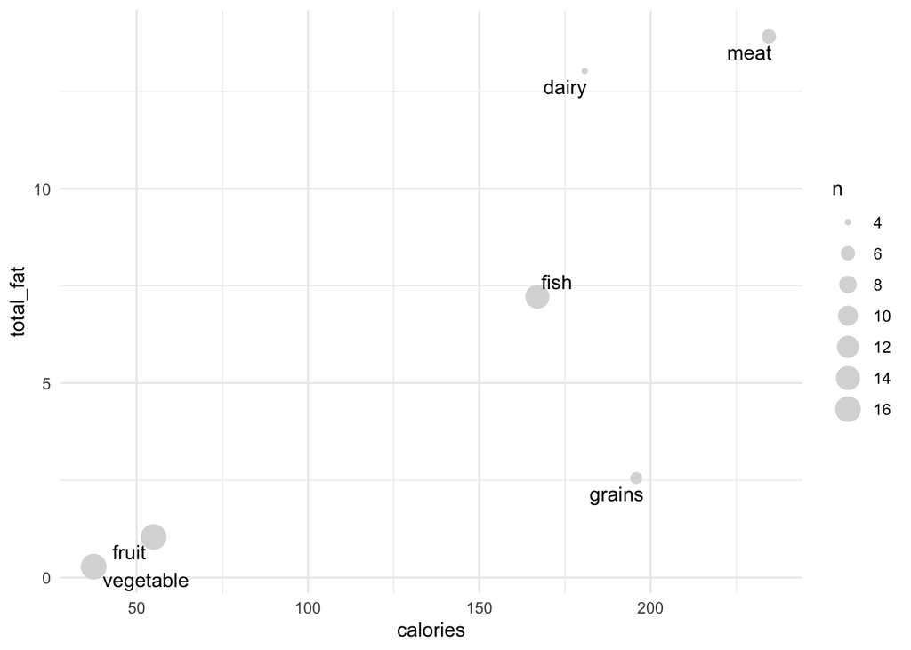

```r
food |>
  group_by(food_group) |>
  summarize(
    calories = mean(calories),
    total_fat = mean(total_fat),
    n = n()
  ) |>
  ggplot(aes(calories, total_fat)) +
  geom_point(aes(size = n), color = "grey85") +
  geom_text_repel(aes(label = food_group))
```

**What’s the deal with `"grey85"`?**

There are many colors available in R, but they all have specific names. To see available colors, try typing `colors()`.

If this seems complex, don’t worry! We are just putting together elements that we have already covered, but it takes some practice before it becomes natural.

Scatter plots are often useful for displaying summarized information. There are two additional `geom` types that often are useful specifically for the case of summarized data sets.

If we want to create a bar plot, where the heights of the bars as given by a column in the data set, we can use the `geom_col` geometry. For this, assign a categorical variable to the `y`-aesthetic and the count variable to the `x`-aesthetic (or vice-versa). For example, here is a bar plot showing the number of items in each food group:

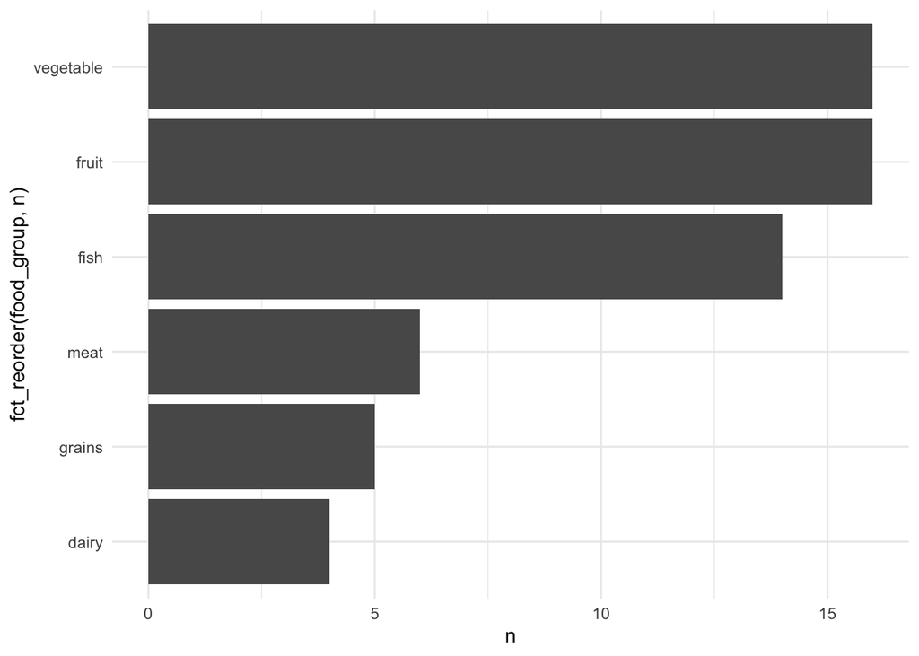

```r
food |>
  group_by(food_group) |>
  summarize(n = n()) |>
  # `fct_reorder` orders the bars (factors) by the count
  ggplot(aes(n, fct_reorder(food_group, n))) +
  geom_col()
```

There are two specific things to keep in mind with the `geom_col` layer. First, there are two color-related `aes` categories: the border of the bars (`color`) and the color used to shade the inside of the bars (`fill`). We can change these exactly as we did with the single color value used with scatter plots.

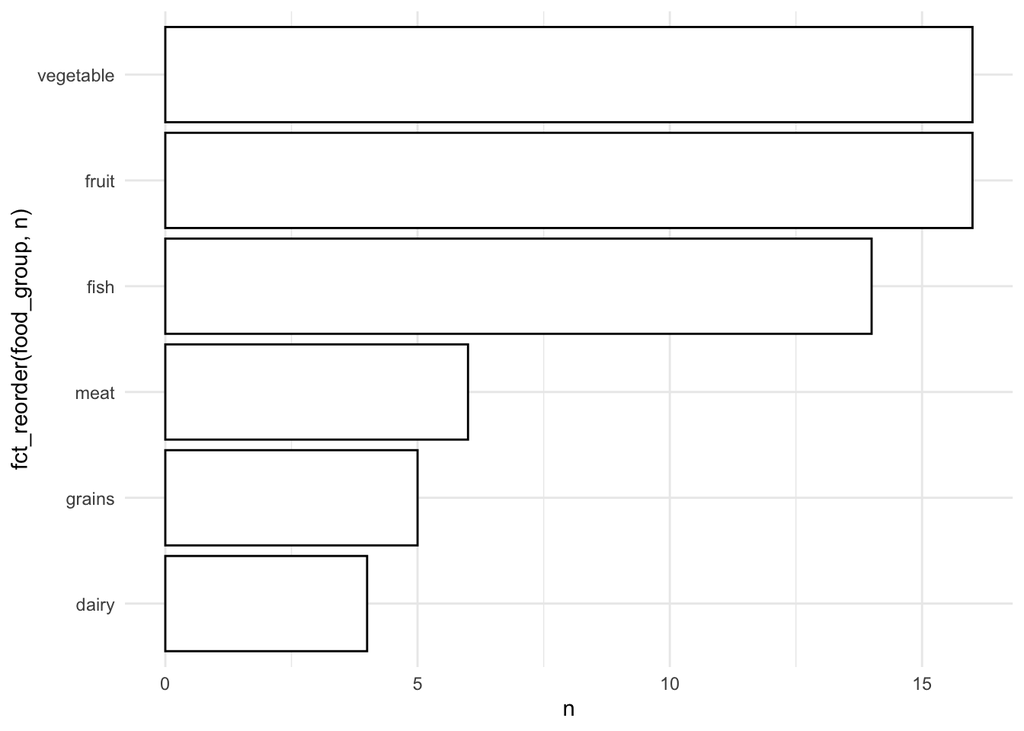

```r
food |>
  group_by(food_group) |>
  summarize(n = n()) |>
  ggplot(aes(n, fct_reorder(food_group, n))) +
  geom_col(color = "black", fill = "white")
```

I find that using a white fill color and a black border is often a good-looking starting point. Also, you will notice that making the bars horizontal will make it easier to read the category names when there are a larger number of categories.

## Multiple groups

As mentioned above, it is possible to group a data set by multiple variables. To do this, we can provide additional variables to the `group_by` function separated by commas. For example, we could group the food data set into food group and color, and summarize each combination of the two:

```r
food |>
  group_by(food_group, color) |>
  summarize(n = n(), calories = mean(calories))
```

| food_group | color | n | calories |
| --- | --- | --- | --- |
| dairy | white | 3 | 124.33333 |
| dairy | yellow | 1 | 350.00000 |
| fish | pink | 2 | 157.50000 |
| fish | red | 3 | 112.33333 |
| fish | white | 9 | 187.22222 |
| fruit | green | 4 | 77.25000 |
| fruit | orange | 3 | 44.66667 |
| fruit | pink | 2 | 35.50000 |
| fruit | purple | 2 | 57.50000 |
| fruit | red | 2 | 42.00000 |

[output cut: 11 more lines]

Notice that now there is one row for each combination of the two groups. However, there is no row for combinations that do not exist. So, there is no row for pink dairy products nor for white fruit.

## Homework Questions

Let’s now take all of the rows from the entire `hans` data set:

| country | continent | year | life_exp | gdp | pop |
| --- | --- | --- | --- | --- | --- |
| Afghanistan | Asia | 1952 | 28.80100 | 779.4453 | 8425333 |
| Afghanistan | Asia | 1957 | 30.33200 | 820.8530 | 9240934 |
| Afghanistan | Asia | 1962 | 31.99700 | 853.1007 | 10267083 |
| Afghanistan | Asia | 1967 | 34.02000 | 836.1971 | 11537966 |
| Afghanistan | Asia | 1972 | 36.08800 | 739.9811 | 13079460 |
| Afghanistan | Asia | 1977 | 38.43800 | 786.1134 | 14880372 |
| Afghanistan | Asia | 1982 | 39.85400 | 978.0114 | 12881816 |
| Afghanistan | Asia | 1987 | 40.82200 | 852.3959 | 13867957 |
| Afghanistan | Asia | 1992 | 41.67400 | 649.3414 | 16317921 |
| Afghanistan | Asia | 1997 | 41.76300 | 635.3414 | 22227415 |

[output cut: 1694 more lines]

For each of the following five questions, write the R code that would produce the desired data set:

1. Compute the average life expectancy from the year 2007.
2. Compute the average GDP from the year 2007.
3. Compute the average life expectancy of each continent in the year 2002.
4. Compute the total number of people living in each continent in the year 1957. Note that R has the function `sum()` that might be helpful here.
5. Compute the total number of countries in each continent.